# Visualizing Plastics: What Global Plastic Audits Reveal

Waste Composition and Environmental Context

Author

Nathan Lee, Noah Nayve, Ryan Ekdahl, Taiga Sobajima

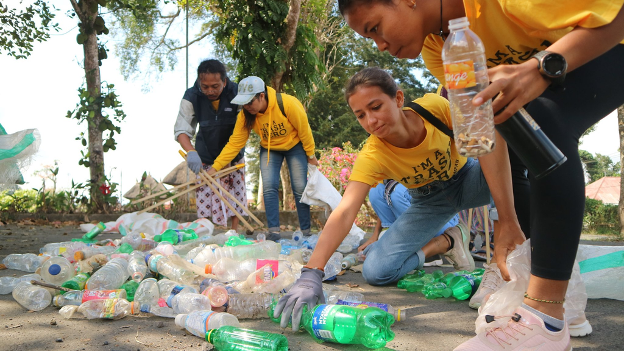

Volunteers participate in a global plastic waste cleanup and brand audit. Image source: Break Free From Plastic, “Branded Vol. II: Identifying the World’s Top Corporate Plastic Polluters,” via Trash Hero World: https://trashhero.org/worlds-top-polluters-revealed-by-break-free-from-plastics-2019-brand-audit/.

Every year, thousands of volunteers around the world collect plastic waste as part of the Break Free From Plastic (BFFP) movement, a global initiative working to stop plastic pollution at its source and hold companies accountable for the waste they produce. The data they gather not only quantifies the scale of plastic pollution, but also reveals how geography shapes the types of waste found across different regions. Using audit data from 2019–2020 across a range of countries, we investigated whether volunteer participation influences the amount of polyethylene plastic collected, and whether country-level environmental indicators, including forest coverage and threatened-species count, are associated with which types of plastic dominate a country’s waste stream.

### Global Plastic Audits Data

The main dataset comes from Sarah Sauve, who cleaned and compiled BFFP’s 2019–2020 brand audit data, in which volunteers around the world collect and report plastic waste. This makes the dataset observational, as it relies on self-reported data submitted by volunteers each year, specifically for 2019 and 2020 in this case. However, the exact methods used by each volunteer are unknown. Each observation represents the plastic collected from a specific parent company within a given country and year. For this analysis, we focused on the country name, parent company (source of plastic), grand total count of all plastics, and number of volunteers. BFFP uses brand audits to raise awareness about plastic pollution and hold companies accountable for the waste associated with their products.

That said, this dataset has some important limitations and potential inconsistencies to consider. The data depends on where volunteers are located, meaning it is more likely to be collected in accessible areas, which can lead to over- or under- representation in some regions and introduce bias. Due to the nature of self-reported data, there is no way for us to verify the accuracy, and there may also be variability in how the plastic is classified and reported to BFFP despite clear definitions. Since our analysis spans both 2019 and 2020, not all countries have data for both years, meaning averages for some countries reflect only a single year. Furthermore, some countries did not record data for certain plastic types; since there are entries with zero, these missing values couldn’t be assumed to mean zero and were instead excluded from proportion calculations and displayed as — in tables.

### Adding Country-Level Context

To expand our analysis, we joined this data to country-level information from API Ninjas, a software company that publishes real-world data into formatted APIs. The Country API aggregates geographic, demographic, and economic metrics for every country in the world which can be found at: https://api-ninjas.com/api/country. Each observation represents a single country’s nation-level statistics. For example, a single row might represent the United States, containing values such as a population of approximately 331 million, a GDP of roughly $23 trillion, and an unemployment rate around 5%. We were interested in the ecological context this dataset provided, focusing specifically on each country’s forest coverage and number of threatened species.

Again, this dataset also has important limitations to keep in mind. API Ninjas does not include collection dates or timestamps for individual records, so we were unable to determine how recent each country’s data was collected or updated. Additionally, since the exact source for each variable is not listed, it was difficult to determine the reliability of certain metrics collected. There were discrepancies in how each country name was displayed between API Ninjas and the plastics data, requiring standardization prior to merging. Several countries in the plastics dataset lacked ecological data in the API and were therefore excluded from the ecological analysis.

### Do More Volunteers Mean More Polyethylene Found?

We started by examining whether countries with more volunteers tend to collect more polyethylene, one of the most widely used plastic types globally, found in everyday items like bags, bottles, trash cans, and containers. Specifically, we looked at both high density polyethylene (HDPE), found in rigid items like milk jugs and shampoo bottles, and low density polyethylene (LDPE), found in flexible items like plastic bags and squeeze bottles.

```r
summarize_plastic_volunteer <- function(polyethylene, country_name, data = plastics) {
  # check to see if polyethylene and country_name is in the data frame
  if (
    !(polyethylene %in% c("ldpe", "hdpe"))
    ) {
    stop(
      paste("Plastic type not found or is not polyethylene kind:", polyethylene)
      )
    }

  if (
    !(country_name %in% data$country)
    ) {
    stop(
      paste("Country not found:", country_name)
      )
    }

  # setting column names for output
  caps_dpe <- toupper(polyethylene)
  avg_col <- glue("Ave_{caps_dpe}")
  percent_col <- glue("Percent_{caps_dpe}")
  total_col <- glue("Total_Plastic")

  # main body finding summary stats of volunteer and plastic type
  result <- data |>
    filter(country == country_name, parent_company != "Grand Total") |>
    mutate(percent_plastic_type = .data[[polyethylene]] / grand_total) |>
    summarise(
      !!avg_col := mean(.data[[polyethylene]], na.rm = TRUE),
      !!percent_col := sum(percent_plastic_type, na.rm = TRUE) /
                        sum(!is.na(percent_plastic_type)) * 100,
      !!total_col := sum(grand_total, na.rm = TRUE),
      Ave_Vol = mean(unique(volunteers)),
      Total_Vol = sum(unique(volunteers))
    ) |>
    mutate(
      across(where(is.numeric), ~round(., 2)),
      !!percent_col := paste0(.data[[percent_col]], "%")
    )

  return(result)
}
```

We started with the United States, the country we live in, to establish a baseline. Below are HDPE and volunteer statistics for the US across 2019 and 2020.

```r
summarize_plastic_volunteer("hdpe", "United States of America") |>
  gt() |>
  tab_header(
    title =  md("**High Density Polyethylene Summary**"),
    subtitle = "United States of America") |>
  tab_caption("Table 1: Summary statistics for high density polyethylene plastic collected in the USA") |>
  tab_spanner(
    label = "HDPE Metrics",
    columns = c(Ave_HDPE, Percent_HDPE, Total_Plastic)
    ) |>
  tab_spanner(
    label = "Volunteer Metrics",
    columns = c(Ave_Vol, Total_Vol)
    ) |>
  cols_label(
    Ave_HDPE = "Avg HDPE",
    Percent_HDPE = "% HDPE",
    Total_Plastic = "Total Plastic",
    Ave_Vol = "Avg Volunteers",
    Total_Vol = "Total Volunteers"
  ) |>
  tab_style(
    style = cell_fill(color = "#457B9D"),
    locations = cells_column_labels()
  ) |>
  tab_style(
    style = cell_text(color = "white", weight = "bold"),
    locations = cells_column_labels()
  ) |>
  tab_style(
    style = cell_fill(color = "#1D3557"),
    locations = cells_column_spanners()
  ) |>
  tab_style(
    style = cell_text(color = "white", weight = "bold"),
    locations = cells_column_spanners()
  )
```

Table 1: Summary statistics for high density polyethylene plastic collected in the USA

**High Density Polyethylene Summary**

United States of America

| HDPE Metrics Avg HDPE | HDPE Metrics % HDPE | HDPE Metrics Total Plastic | Volunteer Metrics Avg Volunteers | Volunteer Metrics Total Volunteers |
| --- | --- | --- | --- | --- |
| 0.7 | 9.21% | 18308 | 625.5 | 1251 |

Table 1 shows HDPE and volunteer statistics for the United States. The USA averaged 625.5 volunteers across 2019 and 2020, with only 9.21% of plastic collected being HDPE, and a mean of 0.7 HDPE pieces per parent company. To see whether this proportion was low compared to other polyethylene types, we next looked at LDPE in the same country.

```r
summarize_plastic_volunteer("ldpe", "United States of America") |>
  gt() |>
  tab_header(
    title =  md("**Low Density Polyethylene Summary**"),
    subtitle = "United States of America") |>
  tab_caption("Table 2: Summary statistics for low density polyethylene plastic collected in the USA") |>
  tab_spanner(
    label = "LDPE Metrics",
    columns = c(Ave_LDPE, Percent_LDPE, Total_Plastic)
    ) |>
  tab_spanner(
    label = "Volunteer Metrics",
    columns = c(Ave_Vol, Total_Vol)
    ) |>
  cols_label(
    Ave_LDPE = "Avg LDPE",
    Percent_LDPE = "% LDPE",
    Total_Plastic = "Total Plastic",
    Ave_Vol = "Avg Volunteers",
    Total_Vol = "Total Volunteers"
  ) |>
  tab_style(
    style = cell_fill(color = "#457B9D"),
    locations = cells_column_labels()
  ) |>
  tab_style(
    style = cell_text(color = "white", weight = "bold"),
    locations = cells_column_labels()
  ) |>
  tab_style(
    style = cell_fill(color = "#1D3557"),
    locations = cells_column_spanners()
  ) |>
  tab_style(
    style = cell_text(color = "white", weight = "bold"),
    locations = cells_column_spanners()
  )
```

Table 2: Summary statistics for low density polyethylene plastic collected in the USA

**Low Density Polyethylene Summary**

United States of America

| LDPE Metrics Avg LDPE | LDPE Metrics % LDPE | LDPE Metrics Total Plastic | Volunteer Metrics Avg Volunteers | Volunteer Metrics Total Volunteers |
| --- | --- | --- | --- | --- |
| 1.04 | 14.69% | 18308 | 625.5 | 1251 |

In the same US audit data, LDPE made up a larger share of reported plastic than HDPE. Table 2 shows these statistics, with 14.69% of the plastic being of the LDPE type and more than one LDPE plastic being collected for every parent company, on average. To see how this compares across countries, we next looked at Indonesia, a country with nearly six times the average volunteers of the US.

```r
summarize_plastic_volunteer("hdpe", "Indonesia") |>
  gt() |>
  tab_header(
    title =  md("**High Density Polyethylene Summary**"),
    subtitle = "Indonesia") |>
  tab_caption("Table 3: Summary statistics for high density polyethylene plastic collected in Indonesia") |>
  tab_spanner(
    label = "HDPE Metrics",
    columns = c(Ave_HDPE, Percent_HDPE, Total_Plastic)
    ) |>
  tab_spanner(
    label = "Volunteer Metrics",
    columns = c(Ave_Vol, Total_Vol)
    ) |>
  cols_label(
    Ave_HDPE = "Avg HDPE",
    Percent_HDPE = "% HDPE",
    Total_Plastic = "Total Plastic",
    Ave_Vol = "Avg Volunteers",
    Total_Vol = "Total Volunteers"
  ) |>
  tab_style(
    style = cell_fill(color = "#457B9D"),
    locations = cells_column_labels()
  ) |>
  tab_style(
    style = cell_text(color = "white", weight = "bold"),
    locations = cells_column_labels()
  ) |>
  tab_style(
    style = cell_fill(color = "#1D3557"),
    locations = cells_column_spanners()
  ) |>
  tab_style(
    style = cell_text(color = "white", weight = "bold"),
    locations = cells_column_spanners()
  )
```

Table 3: Summary statistics for high density polyethylene plastic collected in Indonesia

**High Density Polyethylene Summary**

Indonesia

| HDPE Metrics Avg HDPE | HDPE Metrics % HDPE | HDPE Metrics Total Plastic | Volunteer Metrics Avg Volunteers | Volunteer Metrics Total Volunteers |
| --- | --- | --- | --- | --- |
| 1.61 | 4.25% | 23465 | 3621 | 7242 |

As shown in Table 3, despite its high total volunteer count of 7,242, the amount of HDPE plastic collected was less than half of the US, with only 4.25%. This suggests that environmental and other country-specific conditions play a major role in what types of plastic are collected. Volunteer count alone doesn’t tell the whole story. To further investigate this, we compared the top and bottom 5 countries by average volunteers per company entry for both high and low density polyethylene.

```r
# top and bottom 5 countries
top5_countries <- plastics |>
  filter(parent_company != "Grand Total") |>
  group_by(country) |>
  summarise(ave_vol = mean(unique(volunteers))) |>
  slice_max(ave_vol, n = 5) |>
  pull(country)

bot5_countries <- plastics |>
  filter(parent_company != "Grand Total") |>
  group_by(country) |>
  summarise(ave_vol = mean(unique(volunteers))) |>
  slice_min(ave_vol, n = 5) |>
  pull(country)

# hdpe table
top5_hdpe <- map(top5_countries, ~summarize_plastic_volunteer("hdpe", .x) |>
                   mutate(Country = .x, .before = 1)) |>
  list_rbind()
bot5_hdpe <- map(bot5_countries, ~summarize_plastic_volunteer("hdpe", .x) |>
                   mutate(Country = .x, .before = 1)) |>
  list_rbind()

bind_rows(
  top5_hdpe |> mutate(Group = "Top 5", .before = 2),
  bot5_hdpe |> mutate(Group = "Bottom 5", .before = 2)
) |>
    mutate(
  across(where(is.numeric), ~ifelse(is.nan(.), NA, .)),
  across(where(is.character), ~ifelse(. == "NaN%", "—", .))
  ) |>
  gt() |>
  tab_header(
    title =  md("**High Density Polyethylene Summary**"),
    subtitle = "Top and Bottom 5 Average Volunteer Countries") |>
  tab_caption("Table 4: Summary statistics for high density polyethylene plastic collected in the top and bottom 5 volunteer countries") |>
  tab_spanner(
    label = "Location",
    columns = c(Country, Group)
  ) |>
  tab_spanner(
    label = "HDPE Metrics",
    columns = c(Ave_HDPE, Percent_HDPE, Total_Plastic)
    ) |>
  tab_spanner(
    label = "Volunteer Metrics",
    columns = c(Ave_Vol, Total_Vol)
    ) |>
  cols_label(
    Ave_HDPE = "Avg HDPE",
    Percent_HDPE = "% HDPE",
    Total_Plastic = "Total Plastic",
    Ave_Vol = "Avg Volunteers",
    Total_Vol = "Total Volunteers"
  ) |>
  tab_style(
    style = cell_fill(color = "#457B9D"),
    locations = cells_column_labels()
  ) |>
  tab_style(
    style = cell_text(color = "white", weight = "bold"),
    locations = cells_column_labels()
  ) |>
  tab_style(
    style = cell_fill(color = "#1D3557"),
    locations = cells_column_spanners()
  ) |>
  tab_style(
    style = cell_text(color = "white", weight = "bold"),
    locations = cells_column_spanners()
  )
```

Table 4: Summary statistics for high density polyethylene plastic collected in the top and bottom 5 volunteer countries

**High Density Polyethylene Summary**

Top and Bottom 5 Average Volunteer Countries

| Location Country | Location Group | HDPE Metrics Avg HDPE | HDPE Metrics % HDPE | HDPE Metrics Total Plastic | Volunteer Metrics Avg Volunteers | Volunteer Metrics Total Volunteers |
| --- | --- | --- | --- | --- | --- | --- |
| Taiwan | Top 5 | NA | — | 120646 | 31318.0 | 31318 |
| Bhutan | Top 5 | NA | — | 3500 | 5300.0 | 5300 |
| Indonesia | Top 5 | 1.61 | 4.25% | 23465 | 3621.0 | 7242 |
| Colombia | Top 5 | 14.28 | 20.27% | 7071 | 2763.5 | 5527 |
| Philippines | Top 5 | 1.83 | 1.65% | 92200 | 2333.0 | 4666 |
| Maldives | Bottom 5 | NA | — | 26 | 2.0 | 2 |
| Kuwait | Bottom 5 | 1.95 | 0.77% | 935 | 3.0 | 3 |
| Ireland | Bottom 5 | 0.00 | 0% | 280 | 4.0 | 8 |
| Singapore | Bottom 5 | 1.88 | 21.14% | 95 | 4.0 | 4 |
| Armenia | Bottom 5 | 0.00 | 0% | 8 | 6.0 | 6 |

```r
# ldpe table
top5_ldpe <- map(top5_countries, ~summarize_plastic_volunteer("ldpe", .x) |>
                   mutate(Country = .x, .before = 1)) |>
  list_rbind()
bot5_ldpe <- map(bot5_countries, ~summarize_plastic_volunteer("ldpe", .x) |>
                   mutate(Country = .x, .before = 1)) |>
  list_rbind()

bind_rows(
  top5_ldpe |> mutate(Group = "Top 5", .before = 2),
  bot5_ldpe |> mutate(Group = "Bottom 5", .before = 2)
) |>
    mutate(
      across(where(is.numeric), ~ifelse(is.nan(.), NA, .)),
      across(where(is.character), ~ifelse(. == "NaN%", "—", .))
      ) |>
  gt() |>
  tab_header(
    title =  md("**Low Density Polyethylene Summary**"),
    subtitle = "Top and Bottom 5 Average Volunteer Countries") |>
  tab_caption("Table 5: Summary statistics for low density polyethylene plastic collected in the top and bottom 5 volunteer countries") |>
  tab_spanner(
    label = "Location",
    columns = c(Country, Group)
  ) |>
  tab_spanner(
    label = "LDPE Metrics",
    columns = c(Ave_LDPE, Percent_LDPE, Total_Plastic)
    ) |>
  tab_spanner(
    label = "Volunteer Metrics",
    columns = c(Ave_Vol, Total_Vol)
    ) |>
  cols_label(
    Ave_LDPE = "Avg LDPE",
    Percent_LDPE = "% LDPE",
    Total_Plastic = "Total Plastic",
    Ave_Vol = "Avg Volunteers",
    Total_Vol = "Total Volunteers"
  ) |>
  tab_style(
    style = cell_fill(color = "#457B9D"),
    locations = cells_column_labels()
  ) |>
  tab_style(
    style = cell_text(color = "white", weight = "bold"),
    locations = cells_column_labels()
  ) |>
  tab_style(
    style = cell_fill(color = "#1D3557"),
    locations = cells_column_spanners()
  ) |>
  tab_style(
    style = cell_text(color = "white", weight = "bold"),
    locations = cells_column_spanners()
  )
```

Table 5: Summary statistics for low density polyethylene plastic collected in the top and bottom 5 volunteer countries

**Low Density Polyethylene Summary**

Top and Bottom 5 Average Volunteer Countries

| Location Country | Location Group | LDPE Metrics Avg LDPE | LDPE Metrics % LDPE | LDPE Metrics Total Plastic | Volunteer Metrics Avg Volunteers | Volunteer Metrics Total Volunteers |
| --- | --- | --- | --- | --- | --- | --- |
| Taiwan | Top 5 | NA | — | 120646 | 31318.0 | 31318 |
| Bhutan | Top 5 | NA | — | 3500 | 5300.0 | 5300 |
| Indonesia | Top 5 | 4.58 | 17.93% | 23465 | 3621.0 | 7242 |
| Colombia | Top 5 | 16.52 | 22.47% | 7071 | 2763.5 | 5527 |
| Philippines | Top 5 | 15.19 | 13.12% | 92200 | 2333.0 | 4666 |
| Maldives | Bottom 5 | NA | — | 26 | 2.0 | 2 |
| Kuwait | Bottom 5 | 1.58 | 5.81% | 935 | 3.0 | 3 |
| Ireland | Bottom 5 | 0.00 | 0% | 280 | 4.0 | 8 |
| Singapore | Bottom 5 | 0.00 | 0% | 95 | 4.0 | 4 |
| Armenia | Bottom 5 | 0.00 | 0% | 8 | 6.0 | 6 |

The inconsistency across top-volunteer countries points to something beyond participation driving plastic composition. In Table 4, Colombia reported HDPE collection of 20.27%, while Indonesia and the Philippines reported less than 5% of the type, showing no clear relationship between average number of volunteers and proportion of HDPE plastic reported. The LDPE data in Table 5 shows a similar lack of pattern.

Narrowing down our scope to HDPE, we zoomed out to all countries to see if this lack of clear relationship held globally.

```r
all_countries <- plastics |>
  distinct(country) |>
  pull(country)

bubble_data <- map(all_countries, ~summarize_plastic_volunteer("hdpe", .x) |>
                     mutate(Country = .x)) |>
  list_rbind() |>
  mutate(Percent_HDPE = as.numeric(str_remove(Percent_HDPE, "%"))) |>
  filter(Percent_HDPE < 100)

bubble_plot <- ggplot(bubble_data, aes(x = Ave_Vol,
                        y = Percent_HDPE,
                        size = Total_Plastic,
                        color = Country,
                        text = paste("Country:", Country,
                                     "<br>Average Volunteers:", Ave_Vol,
                                     "<br>Percent HDPE:", Percent_HDPE, "%",
                                     "<br>Total Plastic:", comma(Total_Plastic))
                        )) +
  geom_point(alpha = 0.7) +
  scale_size_continuous(range = c(2, 15)) +
  scale_x_log10() +
  scale_color_viridis_d() +
  guides(color = "none") +
  theme_minimal() +
  labs(
    title = "Figure 1: Average Volunteers vs. HDPE Plastic (%) by Country",
    subtitle = "Bubble size represents total plastic collected",
    x = "Average Volunteers (log scale)",
    y = "",
    size = "Total Plastic"
  )

ggplotly(bubble_plot, tooltip = "text")
```

[interactive chart not shown]

Figure 1 plots the average number of volunteers against the percentage of HDPE reported across all countries in the dataset. The x-axis was log-scaled to better fit the graph and make the relationship easier to see. Although the trend is minimal, there seems to be a weak positive association, meaning as the average number of volunteers increases, the proportion of HDPE reported increases. This may reflect the fact that HDPE is common in everyday products, though the relationship is weak and should not be interpreted as causal.

Larger bubbles, representing countries with higher total plastic collected, tend to appear toward the right side of the plot. This is expected: countries with more volunteers generally have more people available to collect and report plastic waste. However, this does not necessarily explain the composition of plastic collected, which is our main focus. An outlier here is Indonesia (the furthest right bubble), which has among the highest average volunteers yet reported only 4.25% HDPE, one of the lowest in the dataset. This may arise from differences each country has, such as certain laws advocating for plastic reuse or rules that ban these plastic types. This motivated a closer look at both polyethylene types together, where we compared HDPE and LDPE proportions for the highest and lowest volunteer countries.

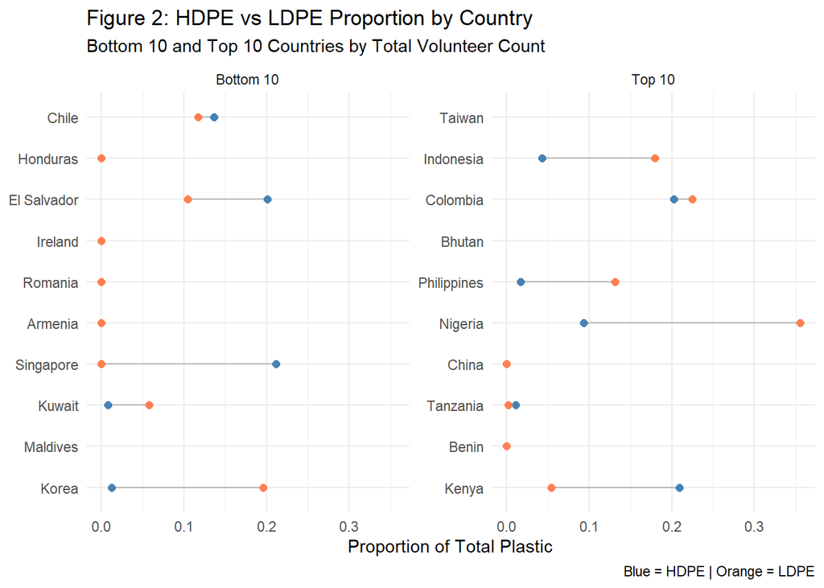

```r
plastics |>
  filter(year %in% c(2019, 2020)) |>
  filter(!country %in% c("Empty", "Grand Total")) |>
  mutate(
    hdpe_prop = hdpe / grand_total,
    ldpe_prop = ldpe / grand_total
  ) |>
  group_by(country) |>
  summarise(
    hdpe_prop = mean(hdpe_prop, na.rm = TRUE),
    ldpe_prop = mean(ldpe_prop, na.rm = TRUE),
    total_volunteers = sum(unique(volunteers), na.rm = TRUE)
  ) |>
  arrange(total_volunteers) |>
  slice(c(1:10, (n()-9):n())) |>
  mutate(
    country = fct_reorder(country, total_volunteers),
    volunteer_group = c(rep("Bottom 10", 10), rep("Top 10", 10))
  ) |>
  ggplot(aes(y = country)) +
  geom_segment(aes(x = hdpe_prop, xend = ldpe_prop, yend = country), color = "gray70") +
  geom_point(aes(x = hdpe_prop), color = "steelblue", size = 2) +
  geom_point(aes(x = ldpe_prop), color = "coral", size = 2) +
  facet_wrap(~ volunteer_group, scales = "free_y") +
  labs(
    title = "Figure 2: HDPE vs LDPE Proportion by Country",
    subtitle = "Bottom 10 and Top 10 Countries by Total Volunteer Count",
    x = "Proportion of Total Plastic",
    y = NULL,
    caption = "Blue = HDPE | Orange = LDPE"
  ) +
  theme_minimal()
```

Figure 2 compares HDPE and LDPE proportions for the top and bottom 10 countries by total volunteer count, placing both polyethylene types side by side. In the top 10 volunteer countries with visible polyethylene proportions, LDPE generally makes up a larger share than HDPE, especially in Nigeria and Indonesia; Kenya is the main exception, where HDPE is higher than LDPE. In contrast, the bottom 10 countries with visible differences more often show HDPE exceeding LDPE, such as in Singapore and El Salvador, while Korea and Kuwait show the opposite pattern. Several countries in both panels have little to no visible polyethylene proportion. Overall, Figure 2 suggests that volunteer count may be associated with different polyethylene composition patterns, but the relationship is inconsistent and country-specific factors still appear important.

### Does a Country’s Environment Shape What Plastic Gets Collected?

Volunteer count showed only a weak and inconsistent relationship with what gets collected. We now turn to a different kind of variable: country-level environmental indicators, specifically forest coverage and threatened-species count.

```r
# function that computes mean of the following variables for each country: country, pet, hdpe, ldpe, pp, ps, pvc, other, forested_area, and threatened_species
summarize_plastic_and_ecology <- function(country_name,
                                   data = population_plastics) {
  if (
    !(country_name %in% data$country)
    ) {
    stop(paste("Country not found:", country_name)
         )
    }

  country_stats <- data |>
    filter(
      country == country_name,
      parent_company == "Grand Total",
      grand_total > 0
      ) |>
    summarize(
      country = country_name,
      avg_pet = mean(pet / grand_total, na.rm = TRUE),
      avg_hdpe = mean(hdpe / grand_total, na.rm = TRUE),
      avg_ldpe = mean(ldpe / grand_total, na.rm = TRUE),
      avg_pp = mean(pp / grand_total, na.rm = TRUE),
      avg_ps = mean(ps / grand_total, na.rm = TRUE),
      avg_pvc = mean(pvc / grand_total, na.rm = TRUE),
      avg_o = mean(o / grand_total, na.rm = TRUE),
      avg_forested = mean(forested_area, na.rm = TRUE),
      avg_threatened = mean(threatened_species, na.rm = TRUE)
    )

# find leading plastic type for each country
leading_plastics <- country_stats |>
    pivot_longer(
      cols = !c(country, avg_forested, avg_threatened),
      names_to = "plastic_type",
      values_to = "avg_value"
    ) |>
    slice_max(order_by = avg_value, n = 1, with_ties = FALSE) |>
    mutate(
      plastic_type = str_remove(plastic_type, "avg_"),
      plastic_type = str_to_upper(plastic_type),
      plastic_type = if_else(plastic_type == "O", "Other", plastic_type)
      ) |>
    pull(plastic_type)

  country_stats |>
    mutate(leading_plastic = leading_plastics)
}

# get all countries with grand_total > 0 and with forest and species data
all_countries <- population_plastics |>
  filter(
    parent_company == "Grand Total",
    grand_total > 0,
    !is.na(forested_area),
    !is.na(threatened_species)
    ) |>
  distinct(country) |>
  pull(country)

# apply the plastic_ecology function to all countries
plastic_ecology_summary_table <- map(all_countries, summarize_plastic_and_ecology) |>
  bind_rows()
```

We grouped countries by forest coverage level and looked at which plastic type dominates in each group.

```r
# make a table by country and forest coverage level
plastic_ecology_summary_table |>
  mutate(
   forest_coverage_level = cut(avg_forested,
                            breaks = c(0, 19, 36, 100),
                            labels = c("Low (< 19%)",
                                       "Medium (19-36%)",
                                       "High (> 36%)"))
  ) |>
  group_by(forest_coverage_level) |>
  slice_min(avg_forested, n = 5) |>
  ungroup() |>
  arrange(avg_forested) |>
  gt(groupname_col = "forest_coverage_level") |>
  tab_caption("Table 6: Plastic type proportions for the 5 least forested countries within each forest coverage level") |>
  tab_header(
  title = "Plastic Type Proportions by Country and Forest Coverage",
  subtitle = "Top 5 least forested countries within each coverage level"
  ) |>
  cols_label(
    country = "Country",
    avg_pet = "PET",
    avg_hdpe = "HDPE",
    avg_ldpe = "LDPE",
    avg_pp = "PP",
    avg_ps = "PS",
    avg_pvc = "PVC",
    avg_o = "Other",
    avg_forested = "Forested Area (%)",
    avg_threatened = "Threatened Species (count)",
    leading_plastic = "Leading Plastic"
  ) |>
  cols_move(
  columns = leading_plastic,
  after = country
  ) |>
  tab_spanner(
    label = "Average Plastic Proportion",
    columns = avg_pet:avg_o
  ) |>
  fmt_percent(columns = avg_pet:avg_o, decimals = 1) |>
  fmt_number(columns = avg_forested, decimals = 1) |>
  fmt_number(columns = avg_threatened, decimals = 0) |>
  tab_style(
    style = cell_text(weight = "bold"),
    locations = cells_column_labels()
  ) |>
  tab_style(
    style = cell_text(weight = "bold"),
    locations = cells_column_spanners()
  ) |>
  tab_style(
  style = cell_fill(color = "#18BC9C"),
  locations = cells_row_groups(groups = "High (> 36%)")
  ) |>
  tab_style(
  style = cell_fill(color = "#F39C12"),
  locations = cells_row_groups(groups = "Medium (19-36%)")
  ) |>
  tab_style(
  style = cell_fill(color = "#E74C3C"),
  locations = cells_row_groups(groups = "Low (< 19%)")
  ) |>
  tab_style(
    style = cell_text(weight = "bold", color = "#2C3E50"),
    locations = cells_body(columns = leading_plastic)
  ) |>
  opt_stylize(style = 6, color = "gray") |>
  tab_options(
  column_labels.background.color = "#2C3E50",
  heading.background.color = "#2C3E50"
  ) |>
  sub_missing(missing_text = "—") |>
  cols_hide(forest_coverage_level)
```

Table 6: Plastic type proportions for the 5 least forested countries within each forest coverage level

Plastic Type Proportions by Country and Forest Coverage

Top 5 least forested countries within each coverage level

| Country | Leading Plastic | Average Plastic Proportion PET | Average Plastic Proportion HDPE | Average Plastic Proportion LDPE | Average Plastic Proportion PP | Average Plastic Proportion PS | Average Plastic Proportion PVC | Average Plastic Proportion Other | Forested Area (%) | Threatened Species (count) |  |  |
| --- | --- | --- | --- | --- | --- | --- | --- | --- | --- | --- | --- | --- |
| Low (< 19%) |  |  |  |  |  |  |  |  |  |  |  |  |
| Maldives | PET | 100.0% | — | — | — | — | — | — |  |  | 3.3 | 80 |
| United Arab Emirates | PET | 91.7% | — | — | — | — | — | 8.3% | 4.5 | 69 |  |  |
| Tunisia | PET | 100.0% | — | — | — | — | — | — | 6.7 | 107 |  |  |
| South Africa | Other | 0.6% | — | — | — | — | — | 99.4% | 7.6 | 597 |  |  |
| Nigeria | PET | 45.0% | 4.6% | 14.5% | 0.9% | 0.1% | 0.0% | 34.8% | 7.7 | 380 |  |  |
| Medium (19-36%) |  |  |  |  |  |  |  |  |  |  |  |  |
| Rwanda | Other | 27.1% | 2.2% | — | — | — | — | 70.7% | 19.5 | 168 |  |  |
| Burkina Faso | PET | 55.9% | — | 35.9% | 1.9% | 0.9% | 0.1% | 5.2% | 19.6 | 36 |  |  |
| China | Other | 34.2% | — | — | — | — | — | 65.8% | 22.1 | 1,172 |  |  |
| India | Other | 11.6% | 0.1% | 32.0% | 3.8% | 4.7% | 0.2% | 47.7% | 23.8 | 1,118 |  |  |
| Philippines | Other | 13.3% | 3.9% | 23.4% | 3.5% | 2.1% | 0.2% | 53.6% | 27.0 | 884 |  |  |
| High (> 36%) |  |  |  |  |  |  |  |  |  |  |  |  |
| Spain | Other | 3.2% | 1.9% | 0.1% | — | — | — | 94.8% | 36.9 | 752 |  |  |
| Benin | PET | 100.0% | — | — | — | — | — | — | 38.2 | 106 |  |  |
| Canada | Other | — | — | — | — | — | — | 100.0% | 38.7 | 173 |  |  |
| Cameroon | LDPE | 38.0% | 6.9% | 39.8% | 3.3% | 0.1% | 0.1% | 11.7% | 39.8 | 890 |  |  |
| Ghana | PET | 100.0% | — | — | — | — | — | — | 41.0 | 255 |  |  |

Table 6 shows the five least forested countries within each forest coverage level. Among countries in the low forest-coverage group, PET dominates as the leading plastic for four out of five entries, with Maldives and Tunisia both reporting 100% PET. South Africa is the only exception, where 99.4% of plastic collected falls under the unclassified Other category. As forest coverage level increases into the medium range, the leading plastic shifts away from PET, where Rwanda, China, India, and the Philippines all report Other as their leading type, with Burkina Faso showing a particularly high LDPE proportion at 35.9%. In the high forest-coverage group, we see Cameroon reporting LDPE as its leading plastic at 39.8%, with two countries reporting Other and PET as their leading plastic types. These results suggest that low forest coverage countries tend to be more heavily dominated by PET plastic, while higher coverage countries show more varied plastic composition, though country-specific reporting differences make direct comparisons difficult. The shift away from PET as forest coverage increases is one of the clearest patterns in the dataset.

Next, we used threatened-species count as a proxy for biodiversity risk to see whether plastic composition followed a similar pattern.

```r
# make a table by country and threatened species level
population_plastics |>
  filter(
    parent_company == "Grand Total",
    grand_total > 0,
    !is.na(threatened_species),
    !is.na(forested_area)
  ) |>
  mutate(
    pet_prop = pet / grand_total,
    hdpe_prop = hdpe / grand_total,
    ldpe_prop = ldpe / grand_total,
    pp_prop = pp / grand_total,
    ps_prop = ps / grand_total,
    pvc_prop = pvc / grand_total,
    o_prop = o / grand_total,
    threatened_species_level = cut(threatened_species,
                      breaks = c(0, 131, 556, Inf),
                      labels = c("Low (< 131)",
                                 "Medium (131-556)",
                                 "High (> 556)"))
  ) |>
  group_by(threatened_species_level) |>
  summarize(
    n_countries = n_distinct(country),
    avg_pet = mean(pet_prop, na.rm = TRUE),
    avg_hdpe = mean(hdpe_prop, na.rm = TRUE),
    avg_ldpe = mean(ldpe_prop, na.rm = TRUE),
    avg_pp = mean(pp_prop, na.rm = TRUE),
    avg_ps = mean(ps_prop, na.rm = TRUE),
    avg_pvc = mean(pvc_prop, na.rm = TRUE),
    avg_o = mean(o_prop, na.rm = TRUE),
    avg_forested = mean(forested_area, na.rm = TRUE)
  ) |>
  gt() |>
  tab_caption("Table 7: Average plastic type composition grouped by threatened-species tier") |>
  tab_header(
    title = "Plastic Type Composition by Threatened-Species Tier"
  ) |>
  cols_label(
    threatened_species_level = "Threatened-Species Tier",
    n_countries  = "Countries",
    avg_pet      = "PET",
    avg_hdpe     = "HDPE",
    avg_ldpe     = "LDPE",
    avg_pp       = "PP",
    avg_ps       = "PS",
    avg_pvc      = "PVC",
    avg_o        = "Other",
    avg_forested = "Avg. Forested Area (%)"
  ) |>
  fmt_percent(columns = avg_pet:avg_o, decimals = 1) |>
  fmt_number(columns = avg_forested, decimals = 1) |>
  tab_spanner(
    label = "Average Plastic Proportion",
    columns = avg_pet:avg_o
  ) |>
  tab_style(
    style = cell_text(weight = "bold"),
    locations = cells_column_labels()
  ) |>
  tab_style(
    style = cell_text(weight = "bold"),
    locations = cells_column_spanners()
  ) |>
  tab_style(
  style = cell_fill(color = "#18BC9C"),
  locations = cells_body(
    columns = threatened_species_level,
    rows = threatened_species_level == "High (> 556)")
  ) |>
  tab_style(
  style = cell_fill(color = "#F39C12"),
  locations = cells_body(
    columns = threatened_species_level,
    rows = threatened_species_level == "Medium (131-556)")
  ) |>
  tab_style(
  style = cell_fill(color = "#E74C3C"),
  locations = cells_body(
    columns = threatened_species_level,
    rows = threatened_species_level == "Low (< 131)")
  ) |>
  tab_options(
  column_labels.background.color = "#2C3E50",
  heading.background.color = "#2C3E50"
  ) |>
  sub_missing(missing_text = "—")
```

Table 7: Average plastic type composition grouped by threatened-species tier

Plastic Type Composition by Threatened-Species Tier

| Threatened-Species Tier | Countries | Average Plastic Proportion PET | Average Plastic Proportion HDPE | Average Plastic Proportion LDPE | Average Plastic Proportion PP | Average Plastic Proportion PS | Average Plastic Proportion PVC | Average Plastic Proportion Other | Avg. Forested Area (%) |  |
| --- | --- | --- | --- | --- | --- | --- | --- | --- | --- | --- |
| Low (< 131) | 14 | 71.7% | 1.5% | 18.0% | 1.9% | 1.6% | 0.1% | 59.7% |  | 28.8 |
| Medium (131-556) | 16 | 38.3% | 10.9% | 6.4% | 18.6% | 23.4% | 1.3% | 57.0% | 25.7 |  |
| High (> 556) | 15 | 21.5% | 12.4% | 21.3% | 10.8% | 5.3% | 0.4% | 58.7% | 37.6 |  |

Table 7 aggregates plastic composition by threatened-species tier across all countries. Most notably, PET proportion drops consistently as threatened-species count increases, from 71.7% in the low tier to 38.3% in the medium tier and 21.5% in the high tier, a drop of over 50 percentage points. HDPE generally increases across these tiers, rising from 1.5% to 10.9% to 12.4% across the low, medium, and high groups, respectively. The Other category remains consistently high across all three tiers at around 57–60%. These results suggest that countries with higher threatened-species counts tend to show a different plastic waste composition, particularly in terms of PET proportion. A 50-point drop in PET proportion from the low to high threatened-species tier is striking and warrants a closer look.

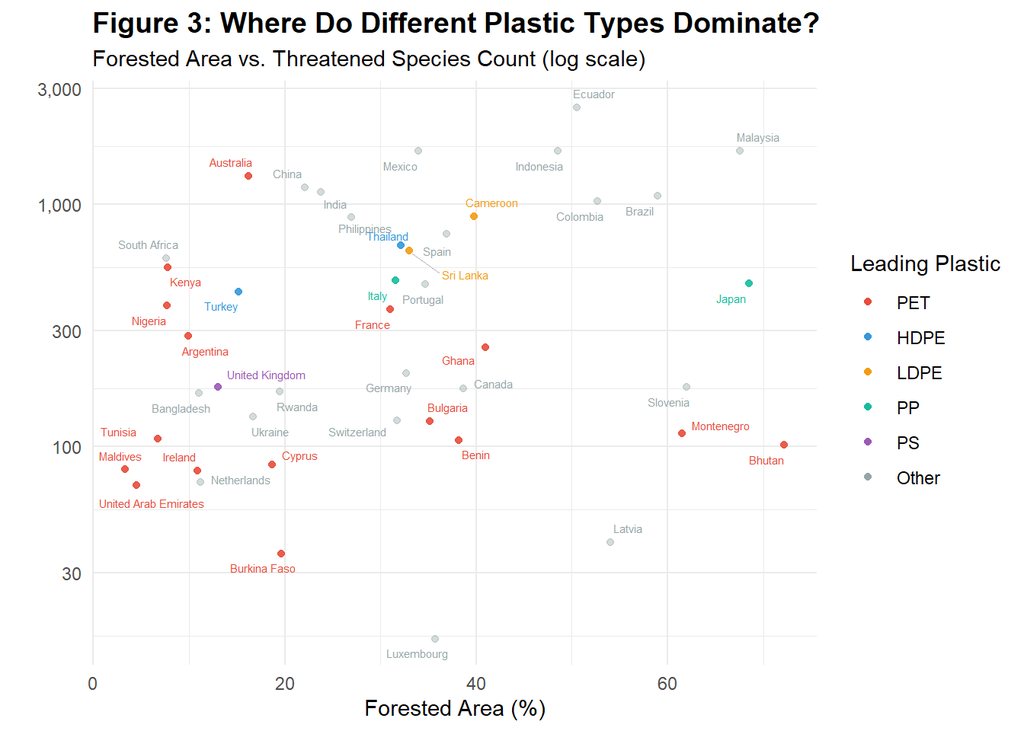

```r
plot_data <- plastic_ecology_summary_table |>
  mutate(
    # reorder legend by frequency, with "Other" pushed to the end
    leading_plastic = fct_infreq(leading_plastic) |>
                      fct_relevel("Other", after = Inf),
    # alpha by group: dim "Other", emphasize named plastics
    point_alpha = if_else(leading_plastic == "Other", 0.4, 0.9)
  )

ggplot(plot_data,
       aes(x = avg_forested,
           y = avg_threatened,
           color = leading_plastic,
           label = country)) +
  geom_point(aes(alpha = point_alpha), size = 1.5) +
  geom_text_repel(size = 2,
                  max.overlaps = Inf,
                  box.padding = 0.25,
                  point.padding = 0.15,
                  segment.color = "gray70",
                  segment.size = 0.25,
                  show.legend = FALSE) +
  scale_y_log10(labels = scales::label_comma()) +
  scale_alpha_identity() +
  scale_color_manual(
    values = c(
      "PET"   = "#E74C3C",
      "HDPE"  = "#3498DB",
      "LDPE"  = "#F39C12",
      "PP"    = "#18BC9C",
      "PS"    = "#9B59B6",
      "PVC"   = "#2C3E50",
      "Other" = "#95A5A6"
    )
  ) +
  labs(
    x = "Forested Area (%)",
    y = "",
    color = "Leading Plastic",
    title = "Figure 3: Where Do Different Plastic Types Dominate?",
    subtitle = "Forested Area vs. Threatened Species Count (log scale)"
  ) +
  theme_minimal() +
  theme(plot.title = element_text(face = "bold", size = 14))
```

The pattern in Table 7 becomes clearer when the environmental variables are viewed together. Figure 3 shows each country’s forested area and threatened-species count, with points colored by leading plastic type. The most noticeable pattern is the clustering of PET-dominated countries in the lower left region of the plot, corresponding to low forest coverage and fewer threatened species. As we move toward higher forest coverage and more threatened species, the leading plastic shifts away from PET. Japan and Cameroon stand out in this region with PP and LDPE as their leading plastics respectively. United Kingdom appears to be an outlier, showing PS as its leading plastic despite relatively low forest coverage. Figure 3 visually reinforces the findings from Tables 6 and 7, illustrating that PET dominance is associated with lower forest coverage and fewer threatened species in this dataset.

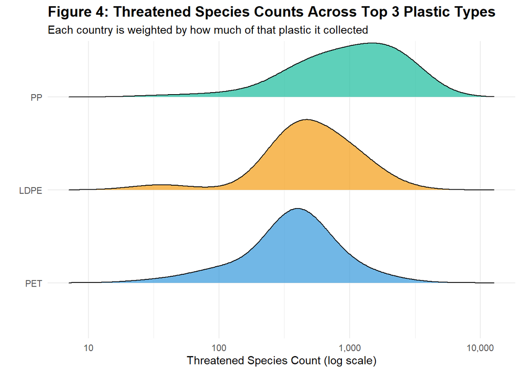

```r
# Identify the three most-collected plastic types in the data
top3_plastics <- population_plastics |>
  filter(parent_company == "Grand Total") |>
  summarize(across(c(pet, hdpe, ldpe, pp, ps, pvc),
                   ~ sum(.x, na.rm = TRUE))) |>
  pivot_longer(everything(),
               names_to = "plastic",
               values_to = "total") |>
  slice_max(total, n = 3) |>
  pull(plastic)

population_plastics |>
  filter(parent_company == "Grand Total",
         grand_total > 0,
         !is.na(threatened_species)) |>
  pivot_longer(cols = all_of(top3_plastics),
               names_to = "plastic_type",
               values_to = "count") |>
  filter(count > 0) |>
  mutate(plastic_type = factor(toupper(plastic_type),
                               levels = toupper(top3_plastics))) |>
  ggplot(aes(x = threatened_species,
             y = plastic_type,
             fill = plastic_type,
             weight = count)) +
  geom_density_ridges(scale = 0.8, alpha = 0.7) +
  scale_x_log10(labels = scales::label_comma()) +
  scale_fill_manual(values = c("#3498DB", "#F39C12", "#18BC9C")) +
  labs(
    title = "Figure 4: Threatened Species Counts Across Top 3 Plastic Types",
    subtitle = "Each country is weighted by how much of that plastic it collected",
    x = "Threatened Species Count (log scale)",
    y = ""
  ) +
  theme_minimal() +
  theme(
    plot.title = element_text(face = "bold", size = 14),
    plot.subtitle = element_text(size = 11),
    legend.position = "none"
  )
```

To look beyond each country’s single leading plastic type, we next focused on the three plastic types with the highest total counts in the audit data: PET, LDPE, and PP. For context, PET is commonly used in drink bottles and food packaging, while PP is used in items such as caps, containers, wrappers, and tubs. Figure 4 shows the distribution of threatened-species counts across these three plastic types, where each country is weighted by how much of that plastic it collected. The PET ridge is centered around 100–500 threatened species, suggesting that PET is more concentrated in countries with lower threatened-species counts. The LDPE ridge shows a similar distribution but is slightly broader, indicating more variability. Finally, the PP ridge shifts furthest to the right, peaking around 1,000 threatened species, suggesting that PP is more common in countries with higher threatened-species counts. This pattern is consistent with Table 7 and Figure 3, further supporting the idea that plastic type composition is associated with threatened-species count.

### Are Country-Level Environmental Indicators Associated With What Plastic Gets Collected?

To examine this pattern more formally, we modeled PET proportion as the outcome variable because PET showed the clearest decline across the environmental summaries and contrasted strongly with PP in Figure 4. We built a linear model predicting PET proportion from forest coverage and threatened-species count. We also included GDP per capita and volunteer count to compare environmental predictors with economic and participation-related factors. The ANOVA table below breaks down how much of the variation in PET proportion each predictor explains.

```r
pet_model <- population_plastics |>
  filter(parent_company == "Grand Total",
         grand_total > 0,
         !is.na(forested_area),
         !is.na(threatened_species),
         !is.na(gdp_per_capita),
         !is.na(volunteers)) |>
  mutate(pet_prop = pet / grand_total) |>
  lm(pet_prop ~ forested_area +
                log(threatened_species) +
                log(gdp_per_capita) +
                volunteers, data = _)

anova_terms <- anova(pet_model) |>
  tidy() |>
  mutate(
    pct_variance = sumsq / sum(sumsq) * 100
  )

coef_terms <- tidy(pet_model) |>
  select(term, estimate)

anova_terms |>
  left_join(coef_terms, by = "term") |>
  mutate(
    term = recode(term,
      "volunteers" = "Volunteers",
      "forested_area" = "Forested Area",
      "log(threatened_species)" = "Threatened Species (log)",
      "log(gdp_per_capita)" = "GDP Per Capita (log)",
      "Residuals" = "Unexplained")
  ) |>
  select(term, estimate, df, sumsq, pct_variance, statistic, p.value) |>
  gt() |>
  tab_caption("Table 8: ANOVA results predicting PET plastic proportion from environmental, economic, and volunteer predictors") |>
  tab_header(
    title = "What Predicts PET Plastic Proportion?",
    subtitle = "Variance in PET proportion partitioned across environmental, economic, and volunteer predictors"
  ) |>
  cols_label(
    term         = "Source",
    estimate     = "Estimate",
    df           = "df",
    sumsq        = "Sum of Squares",
    pct_variance = "% of Variance",
    statistic    = "F",
    p.value      = "p-value"
  ) |>
  fmt_number(columns = estimate, decimals = 4) |>
  fmt_number(columns = c(sumsq, statistic), decimals = 3) |>
  fmt_number(columns = pct_variance, decimals = 1) |>
  fmt_number(columns = p.value, decimals = 4) |>
  sub_missing(missing_text = "—") |>
  tab_style(
    style = cell_text(weight = "bold"),
    locations = cells_column_labels()
  ) |>
  tab_style(
    style = list(cell_fill(color = "#18BC9C"),
                 cell_text(weight = "bold")),
    locations = cells_body(rows = p.value < 0.05)
  ) |>
  tab_options(
    column_labels.background.color = "#2C3E50",
    heading.background.color = "#2C3E50"
  ) |>
  tab_source_note(
    "Note: Estimates show the direction and size of each predictor's association with PET proportion, while the ANOVA columns show how much variation each predictor explains."
  ) |>
  tab_source_note(
    paste0("Model R² = ", round(summary(pet_model)$r.squared, 3),
           " · n = ", nobs(pet_model))
  )
```

Table 8: ANOVA results predicting PET plastic proportion from environmental, economic, and volunteer predictors

What Predicts PET Plastic Proportion?

Variance in PET proportion partitioned across environmental, economic, and volunteer predictors

| Source | Estimate | df | Sum of Squares | % of Variance | F | p-value |
| --- | --- | --- | --- | --- | --- | --- |
| Forested Area | −0.0042 | 1 | 0.449 | 7.0 | 3.259 | 0.0794 |
| Threatened Species (log) | −0.1325 | 1 | 0.805 | 12.5 | 5.841 | 0.0209 |
| GDP Per Capita (log) | −0.0226 | 1 | 0.105 | 1.6 | 0.760 | 0.3892 |
| Volunteers | 0.0000 | 1 | 0.136 | 2.1 | 0.990 | 0.3263 |
| Unexplained | — | 36 | 4.962 | 76.8 | — | — |

Note: Estimates show the direction and size of each predictor's association with PET proportion, while the ANOVA columns show how much variation each predictor explains.  
Model R² = 0.232 · n = 41

We found that the number of threatened species explains 12.5% of the variation in PET proportion (F = 5.841, p = 0.0209). The estimate of -0.1325 indicates that, in this model, higher threatened-species count is associated with lower PET proportion. This aligns with what we saw in Figure 3 that countries with fewer threatened species tended to be more PET-dominated. Forested area pointed in the same direction (estimate = -0.0042, p = 0.0794), though its p-value was not below the 0.05 threshold for statistical significance. Together, the model explains about 23% of the variation in PET proportion, leaving most of the variance unexplained by these predictors. Country-level environmental indicators appear to be meaningful signals of what plastic shows up in audit data, even after accounting for GDP per capita and volunteer participation.

### What the Audits Tell Us

Taken together, the results pointed to something beyond volunteer participation influencing plastic composition. While countries with more volunteers did tend to report higher polyethylene proportions, the relationship was inconsistent. Indonesia had among the highest average volunteers yet reported only 4.25% HDPE, one of the lowest in the dataset, suggesting that country-specific factors like local regulations and consumption habits play a much larger role.

Country-level environmental indicators told a clearer story. Countries with lower forest coverage and fewer threatened species were consistently dominated by PET plastic, while countries with higher forest coverage or more threatened species showed more varied composition. The model supported this pattern, with threatened-species count explaining 12.5% of the variation in PET proportion (p = 0.0209). Forested area pointed in the same direction but fell slightly short of statistical significance.

Again, this analysis has real limitations: volunteers self-report, coverage is uneven across regions, and some countries did not record data for certain plastic types, making it impossible to know whether those plastics were truly absent or simply unreported. Still, the patterns across tables, figures, and the model suggest that country-level context may be associated not just with how much plastic appears in audits, but also with what kind. Future work could explore these country-level differences further to better understand how cleanup efforts could be targeted.